# Week-5

QuickFixDemos

Packages Used Installation

```r
# install.packages("e1071")
# install.packages("caTools")
# install.packages("caret")
# install.packages("bnlearn")
```

```r
library(bnlearn)
library(e1071)
library(caTools)
library(caret)
```

Lab Assignment 5

Learning Objective: Understand the graphical models for inference under uncertainty, build Bayesian Network in R, Learn the structure and CPTs from Data, naive Bayes classification with dependency between features. Problem Statement: A table containing grades earned by students in respective courses is made available to you in (codes folder) 2020_bn_nb_data.txt. Q1: Consider grades earned in each of the courses as random variables and learn the dependencies between courses. ##Solution

```r
dataset<-read.table("C:/Users/shiva/OneDrive/Desktop/Semester-6/AILab/Lab5/2020_bn_nb_data.txt",head=TRUE,stringsAsFactors=TRUE)
dataset_grades=dataset
dataset_net<-hc(dataset_grades,score="k2")
dataset_net
```

```
  Bayesian network learned via Score-based methods

  model:
   [MA101][EC100|MA101][PH100|EC100][QP|EC100][EC160|QP][IT101|QP][PH160|QP][HS101|QP][IT161|IT101]
  nodes:                                 9
  arcs:                                  8
    undirected arcs:                     0
    directed arcs:                       8
  average markov blanket size:           1.78
  average neighbourhood size:            1.78
  average branching factor:              0.89

  learning algorithm:                    Hill-Climbing
  score:                                 Cooper & Herskovits' K2
  tests used in the learning procedure:  168
  optimized:                             TRUE
```

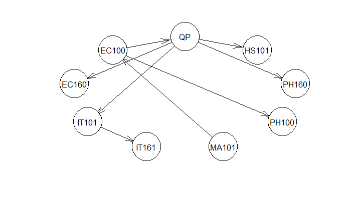

```r
plot(dataset_net)
```

Q2: Using the data, learn the CPTs for each course node.

```r
dataset_net_bn_fit <- bn.fit(dataset_net, dataset_grades )
print(dataset_net_bn_fit)
```

```
  Bayesian network parameters

  Parameters of node EC100 (multinomial distribution)

Conditional probability table:

     MA101
EC100         AA         AB         BB         BC         CC         CD         DD          F
   AA 0.75000000 0.07692308 0.03846154 0.01851852 0.00000000 0.00000000 0.00000000 0.00000000
   AB 0.00000000 0.46153846 0.25000000 0.05555556 0.00000000 0.00000000 0.00000000 0.00000000
   BB 0.25000000 0.23076923 0.32692308 0.22222222 0.04081633 0.00000000 0.00000000 0.00000000
   BC 0.00000000 0.15384615 0.28846154 0.27777778 0.32653061 0.00000000 0.00000000 0.00000000
   CC 0.00000000 0.07692308 0.09615385 0.24074074 0.32653061 0.04166667 0.00000000 0.00000000
   CD 0.00000000 0.00000000 0.00000000 0.12962963 0.26530612 0.33333333 0.04761905 0.00000000
   DD 0.00000000 0.00000000 0.00000000 0.03703704 0.04081633 0.50000000 0.19047619 0.00000000
   F  0.00000000 0.00000000 0.00000000 0.01851852 0.00000000 0.12500000 0.76190476 1.00000000

  Parameters of node EC160 (multinomial distribution)

Conditional probability table:

     QP
EC160          n          y
   AA 0.00000000 0.07500000
   AB 0.00000000 0.10000000
   BB 0.01388889 0.18750000
   BC 0.01388889 0.36250000
   CC 0.15277778 0.22500000
   CD 0.44444444 0.03125000
   DD 0.26388889 0.01875000
   F  0.11111111 0.00000000

  Parameters of node IT101 (multinomial distribution)

Conditional probability table:

     QP
IT101          n          y
   AA 0.00000000 0.07500000
   AB 0.00000000 0.15625000
```

[output cut: 66 more lines]

```
   BB 0.05555556 0.22500000
   BC 0.12500000 0.16875000
   CC 0.18055556 0.08125000
   CD 0.19444444 0.03750000
   DD 0.37500000 0.01250000
   F  0.06944444 0.00000000

  Parameters of node QP (multinomial distribution)

Conditional probability table:

   EC100
QP         AA        AB        BB        BC        CC        CD        DD         F
  n 0.0000000 0.0000000 0.0000000 0.0000000 0.1388889 0.4482759 0.9500000 1.0000000
  y 1.0000000 1.0000000 1.0000000 1.0000000 0.8611111 0.5517241 0.0500000 0.0000000
```

Q3: What grade will a student get in PH100 if he earns DD in EC100, CC in IT101 and CD in MA101.

```r
grade_list <- list("AA","AB","BB","BC","CC","CD","DD","F")
probability <- 0.0
result=""
for(grade in grade_list) {
  prob <- cpquery(dataset_net_bn_fit, event = (PH100== grade), evidence = (EC100=="DD" & IT101=="CC" & MA101=="CD"))
  if(probability<prob){
    probability=prob;
    result=grade
  }
}
sprintf("The max probability of resultant grade is %f",probability)
```

```
[1] "The max probability of resultant grade is 0.434599"
```

```r
sprintf("The max grade obtained with given ecidence is %s ",result)
```

```
[1] "The max grade obtained with given ecidence is CD "
```

Q4(a): The last column in the data file indicates whether a student qualifies for an internship program or not. From the given data, take 70 percent data for training and build a naive Bayes classifier (considering that the grades earned in different courses are independent of each other) which takes in the student’s performance and returns the qualification status with a probability. Test your classifier on the remaining 30 percent data. Repeat this experiment for 20 random selection of training and testing data. Report results about the accuracy of your classifier.

```r
dataset_grades=dataset
split <- sample.split(dataset_grades, SplitRatio = 0.7)
train <- subset(dataset_grades, split == "TRUE")
test <- subset(dataset_grades, split == "FALSE")
naive_bayes_classifier<- naiveBayes(QP ~ ., data = train)
y_train=predict(naive_bayes_classifier, newdata = train)
y_prediction <- predict(naive_bayes_classifier, newdata = test)
cm_train<- table(train$QP, y_train)
accuracy_train = (cm_train[1,1]+cm_train[2,2])/sum(cm_train)
print(round(cbind("Train Accuracy" =accuracy_train), 4))
```

```
     Train Accuracy
[1,]         0.9935
```

```r
cm_test <- table(test$QP, y_prediction)
accuracy_test = (cm_test[1,1]+cm_test[2,2])/sum(cm_test)
print(round(cbind("Test Accuracy" =accuracy_test), 4))
```

```
     Test Accuracy
[1,]        0.9351
```

Q4(b): Repeat this experiment for 20 random selection of training and testing data. Report results about the accuracy of your classifier.

```r
dataset_grades=dataset
dataset_grades=dataset_grades[sample(nrow(dataset_grades), 20), ]
split <- sample.split(dataset_grades, SplitRatio = 0.7)
train <- subset(dataset_grades, split == "TRUE")
test <- subset(dataset_grades, split == "FALSE")
naive_bayes_classifier<- naiveBayes(QP ~ ., data = train)
y_train=predict(naive_bayes_classifier, newdata = train)
y_prediction <- predict(naive_bayes_classifier, newdata = test)
cm_train<- table(train$QP, y_train)
accuracy_train = (cm_train[1,1]+cm_train[2,2])/sum(cm_train)
print(round(cbind("Train Accuracy" =accuracy_train), 4))
```

```
     Train Accuracy
[1,]              1
```

```r
cm_test <- table(test$QP, y_prediction)
accuracy_test = (cm_test[1,1]+cm_test[2,2])/sum(cm_test)
print(round(cbind("Test Accuracy" =accuracy_test), 4))
```

```
     Test Accuracy
[1,]        0.8333
```

Q5(a): Repeat 4, considering that the grades earned in different courses may be dependent.

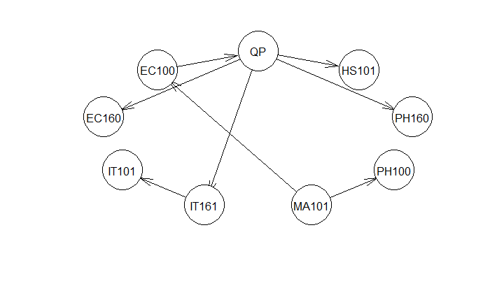

```r
dataset_grades=dataset
split <- sample.split(dataset_grades, SplitRatio = 0.7)
train <- subset(dataset_grades, split == "TRUE")
test <- subset(dataset_grades, split == "FALSE")
train.hc=suppressWarnings(hc(train, score="k2"))
plot(train.hc)
```

```r
naive_bayes_classifier<- suppressWarnings(bn.fit(train.hc, train))
y_train <- predict(naive_bayes_classifier,node="QP", data = train)
y_prediction <- predict(naive_bayes_classifier,node="QP", data = test)
cm_train<- table(train$QP, y_train)
accuracy_train = (cm_train[1,1]+cm_train[2,2])/sum(cm_train)
print(round(cbind("Train Accuracy" =accuracy_train), 4))
```

```
     Train Accuracy
[1,]         0.9091
```

```r
cm_test <- table(test$QP, y_prediction)
accuracy_test = (cm_test[1,1]+cm_test[2,2])/sum(cm_test)
print(round(cbind("Test Accuracy" =accuracy_test), 4))
```

```
     Test Accuracy
[1,]        0.9359
```

Q5(b): Repeat this experiment for 20 random selection of training and testing data. Report results about the accuracy of your classifier.

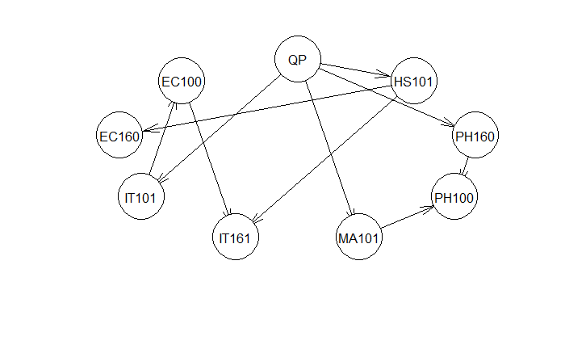

```r
dataset_grades=dataset
dataset_grades=dataset_grades[sample(nrow(dataset_grades), 20), ]
split <- sample.split(dataset_grades, SplitRatio = 0.7)
train <- subset(dataset_grades, split == "TRUE")
test <- subset(dataset_grades, split == "FALSE")
train.hc=suppressWarnings(hc(train, score="k2"))
plot(train.hc)
```

```r
naive_bayes_classifier<- suppressWarnings(bn.fit(train.hc, train))
y_train <- predict(naive_bayes_classifier,node="QP", data = train)
y_prediction <- predict(naive_bayes_classifier,node="QP", data = test)
cm_train<- table(train$QP, y_train)
accuracy_train = (cm_train[1,1]+cm_train[2,2])/sum(cm_train)
print(round(cbind("Train Accuracy" =accuracy_train), 4))
```

```
     Train Accuracy
[1,]         0.8571
```

```r
cm_test <- table(test$QP, y_prediction)
accuracy_test = (cm_test[1,1]+cm_test[2,2])/sum(cm_test)
print(round(cbind("Test Accuracy" =accuracy_test), 4))
```

```
     Test Accuracy
[1,]        0.6667
```